# Franjas

### 07:00-08:00

[interactive chart not shown]

### 08:00-09:00

[interactive chart not shown]

### 09:00-12:00

[interactive chart not shown]

### 12:00-13:30

[interactive chart not shown]

### 13:30-14:30

[interactive chart not shown]

### 14:30-15:30

[interactive chart not shown]

### 15:30-16:30

[interactive chart not shown]

### 16:30-18:30

[interactive chart not shown]

### 18:30-19:30

[interactive chart not shown]

### 19:30-20:30

[interactive chart not shown]

### 20:30-21:30

[interactive chart not shown]

### 21:30-22:30

[interactive chart not shown]

### 22:30-23:07

[interactive chart not shown]

# Grid

[interactive chart not shown]

# Serie conjunta

[interactive chart not shown]

# Resumen

Días con variaciones mayores al 10% (últimas 8 semanas)

07:00

| Date | Description | rat# | Inicio | rat_prev | variación |
| --- | --- | --- | --- | --- | --- |
| 2026-09-17 | DESPIERTA | 986 | 07:00 | 650 | 51.6 |
| 2026-09-29 | DESPIERTA | 1062 | 07:00 | 731 | 45.3 |
| 2026-09-21 | DESPIERTA | 1160 | 07:00 | 808 | 43.6 |
| 2026-09-07 | DESPIERTA | 1139 | 07:00 | 876 | 30 |
| 2026-09-08 | DESPIERTA | 828 | 07:00 | 1139 | -27.3 |
| 2026-09-30 | DESPIERTA | 790 | 07:00 | 1062 | -25.6 |
| 2026-09-22 | DESPIERTA | 877 | 07:00 | 1160 | -24.4 |
| 2026-10-08 | DESPIERTA | 1063 | 07:00 | 862 | 23.3 |
| 2026-10-20 | DESPIERTA | 737 | 07:00 | 946 | -22.1 |
| 2026-10-21 | DESPIERTA | 893 | 07:00 | 737 | 21.2 |
| 2026-10-02 | DESPIERTA | 910 | 07:00 | 758 | 20.1 |
| 2026-10-22 | DESPIERTA | 1065 | 07:00 | 893 | 19.4 |
| 2026-10-12 | DESPIERTA | 887 | 07:00 | 1099 | -19.2 |
| 2026-10-14 | DESPIERTA | 806 | 07:00 | 988 | -18.4 |
| 2026-09-18 | DESPIERTA | 808 | 07:00 | 986 | -18.1 |
| 2026-09-16 | DESPIERTA | 650 | 07:00 | 784 | -17 |
| 2026-10-15 | DESPIERTA | 932 | 07:00 | 806 | 15.7 |
| 2026-10-13 | DESPIERTA | 988 | 07:00 | 887 | 11.3 |
| 2026-10-23 | DESPIERTA | 953 | 07:00 | 1065 | -10.5 |
| 2026-09-28 | DESPIERTA | 731 | 07:00 | 817 | -10.4 |
| 2026-10-26 | DESPIERTA | 857 | 07:00 | 953 | -10.1 |

08:00

| Date | Description | rat# | Inicio | rat_prev | variación |
| --- | --- | --- | --- | --- | --- |
| 2026-09-21 | DESPIERTA 2 | 1044 | 08:00 | 823 | 26.9 |
| 2026-10-02 | DESPIERTA 2 | 1134 | 08:00 | 900 | 26 |
| 2026-09-08 | DESPIERTA 2 | 811 | 08:00 | 1090 | -25.6 |
| 2026-09-09 | DESPIERTA 2 | 1012 | 08:00 | 811 | 24.8 |
| 2026-09-18 | DESPIERTA 2 | 823 | 08:00 | 1047 | -21.4 |
| 2026-10-08 | DESPIERTA 2 | 1077 | 08:00 | 898 | 19.9 |
| 2026-09-17 | DESPIERTA 2 | 1047 | 08:00 | 874 | 19.8 |
| 2026-10-28 | DESPIERTA 2 | 1235 | 08:00 | 1033 | 19.5 |
| 2026-09-11 | DESPIERTA 2 | 814 | 08:00 | 1002 | -18.8 |
| 2026-10-05 | DESPIERTA 2 | 955 | 08:00 | 1134 | -15.8 |
| 2026-09-29 | DESPIERTA 2 | 877 | 08:00 | 1025 | -14.4 |
| 2026-10-14 | DESPIERTA 2 | 947 | 08:00 | 1086 | -12.8 |
| 2026-09-14 | DESPIERTA 2 | 912 | 08:00 | 814 | 12.1 |
| 2026-10-20 | DESPIERTA 2 | 947 | 08:00 | 1073 | -11.8 |
| 2026-10-01 | DESPIERTA 2 | 900 | 08:00 | 810 | 11.2 |
| 2026-10-13 | DESPIERTA 2 | 1086 | 08:00 | 981 | 10.6 |
| 2026-09-07 | DESPIERTA 2 | 1090 | 08:00 | 987 | 10.5 |
| 2026-10-15 | DESPIERTA 2 | 1043 | 08:00 | 947 | 10.1 |

09:00

| Date | Description | rat# | Inicio | rat_prev | variación |
| --- | --- | --- | --- | --- | --- |
| 2026-10-05 | HOY | 1724 | 09:00 | 1374 | 25.5 |
| 2026-10-06 | HOY | 1380 | 09:00 | 1724 | -19.9 |
| 2026-10-27 | HOY | 1538 | 09:00 | 1284 | 19.8 |
| 2026-10-07 | HOY | 1584 | 09:00 | 1380 | 14.8 |
| 2026-10-08 | HOY | 1353 | 09:00 | 1584 | -14.6 |
| 2026-10-23 | HOY | 1431 | 09:00 | 1674 | -14.5 |
| 2026-10-16 | HOY | 1589 | 09:00 | 1399 | 13.6 |
| 2026-10-02 | HOY | 1374 | 09:00 | 1590 | -13.6 |
| 2026-10-22 | HOY | 1674 | 09:00 | 1496 | 11.9 |
| 2026-10-12 | HOY | 1567 | 09:00 | 1416 | 10.7 |
| 2026-10-26 | HOY | 1284 | 09:00 | 1431 | -10.3 |

12:00

| Date | Description | rat# | Inicio | rat_prev | variación |
| --- | --- | --- | --- | --- | --- |
| 2026-10-27 | CUENTAMELO YA! | 1611 | 12:00 | 1270 | 26.9 |
| 2026-10-26 | CUENTAMELO YA! | 1270 | 12:00 | 1696 | -25.1 |
| 2026-09-09 | CUENTAMELO YA! | 1742 | 12:00 | 1423 | 22.4 |
| 2026-09-21 | CUENTAMELO YA! | 1458 | 12:00 | 1784 | -18.3 |
| 2026-10-13 | CUENTAMELO YA! | 1426 | 12:00 | 1743 | -18.2 |
| 2026-10-20 | CUENTAMELO YA! | 1425 | 12:00 | 1737 | -18 |
| 2026-10-29 | CUENTAMELO YA! | 1769 | 12:00 | 1539 | 14.9 |
| 2026-09-23 | CUENTAMELO YA! | 1411 | 12:00 | 1644 | -14.2 |
| 2026-09-22 | CUENTAMELO YA! | 1644 | 12:00 | 1458 | 12.8 |
| 2026-10-02 | CUENTAMELO YA! | 1488 | 12:00 | 1701 | -12.5 |
| 2026-10-21 | CUENTAMELO YA! | 1601 | 12:00 | 1425 | 12.4 |
| 2026-10-12 | CUENTAMELO YA! | 1743 | 12:00 | 1560 | 11.7 |
| 2026-09-29 | CUENTAMELO YA! | 1780 | 12:00 | 1597 | 11.4 |
| 2026-09-16 | CUENTAMELO YA! | 1546 | 12:00 | 1745 | -11.4 |
| 2026-09-24 | CUENTAMELO YA! | 1571 | 12:00 | 1411 | 11.4 |
| 2026-09-30 | CUENTAMELO YA! | 1583 | 12:00 | 1780 | -11.1 |

13:30

| Date | Description | rat# | Inicio | rat_prev | variación |
| --- | --- | --- | --- | --- | --- |
| 2026-09-09 | COMO DICE EL DICHO | 1802 | 13:30 | 1482 | 21.6 |
| 2026-09-18 | COMO DICE EL DICHO | 1840 | 13:30 | 1537 | 19.7 |
| 2026-10-12 | COMO DICE EL DICHO | 1799 | 13:30 | 1504 | 19.6 |
| 2026-10-16 | COMO DICE EL DICHO | 1916 | 13:30 | 1620 | 18.3 |
| 2026-10-19 | COMO DICE EL DICHO | 1593 | 13:30 | 1916 | -16.8 |
| 2026-09-11 | COMO DICE EL DICHO | 1801 | 13:30 | 1543 | 16.8 |
| 2026-09-16 | COMO DICE EL DICHO | 1541 | 13:30 | 1850 | -16.7 |
| 2026-10-22 | COMO DICE EL DICHO | 1738 | 13:30 | 1497 | 16 |
| 2026-10-08 | COMO DICE EL DICHO | 1760 | 13:30 | 1529 | 15.2 |
| 2026-09-15 | COMO DICE EL DICHO | 1850 | 13:30 | 1612 | 14.7 |
| 2026-10-09 | COMO DICE EL DICHO | 1504 | 13:30 | 1760 | -14.6 |
| 2026-09-10 | COMO DICE EL DICHO | 1543 | 13:30 | 1802 | -14.4 |
| 2026-09-08 | COMO DICE EL DICHO | 1482 | 13:30 | 1709 | -13.3 |
| 2026-09-21 | COMO DICE EL DICHO | 1626 | 13:30 | 1840 | -11.6 |
| 2026-10-26 | COMO DICE EL DICHO | 1472 | 13:30 | 1660 | -11.3 |
| 2026-09-14 | COMO DICE EL DICHO | 1612 | 13:30 | 1801 | -10.5 |

14:30

| Date | Description | rat# | Inicio | rat_prev | variación |
| --- | --- | --- | --- | --- | --- |
| 2026-09-28 | EL CHAVO | 2300 | 14:30 | 1919 | 19.8 |
| 2026-10-28 | EL CHAVO | 2107 | 14:30 | 1841 | 14.5 |
| 2026-09-07 | EL CHAVO | 2003 | 14:30 | 2318 | -13.6 |
| 2026-10-14 | EL CHAVO | 1894 | 14:30 | 2185 | -13.3 |
| 2026-10-12 | EL CHAVO | 2206 | 14:30 | 1949 | 13.2 |
| 2026-10-05 | EL CHAVO | 2146 | 14:30 | 1914 | 12.1 |
| 2026-09-30 | EL CHAVO | 1983 | 14:30 | 2255 | -12.1 |

15:30

| Date | Description | rat# | Inicio | rat_prev | variación |
| --- | --- | --- | --- | --- | --- |
| 2026-09-11 | LO TOMAS O LO DEJAS | 2871 | 15:30 | 2299 | 24.9 |
| 2026-10-12 | PIENSA RAPIDO | 2636 | 15:30 | 2278 | 15.7 |
| 2026-10-08 | PIENSA RAPIDO | 2552 | 15:30 | 2207 | 15.7 |
| 2026-09-15 | LO TOMAS O LO DEJAS | 2231 | 15:30 | 2638 | -15.5 |
| 2026-10-21 | PIENSA RAPIDO | 2806 | 15:30 | 2435 | 15.2 |
| 2026-09-28 | PIENSA RAPIDO | 2766 | 15:30 | 2409 | 14.8 |
| 2026-09-25 | PIENSA RAPIDO | 2409 | 15:30 | 2742 | -12.1 |
| 2026-10-09 | PIENSA RAPIDO | 2278 | 15:30 | 2552 | -10.7 |

16:30

| Date | Description | rat# | Inicio | rat_prev | variación |
| --- | --- | --- | --- | --- | --- |
| 2026-09-15 | RUBI | 2755 | 16:30 | 3525 | -21.8 |
| 2026-09-16 | RUBI | 3235 | 16:30 | 2755 | 17.4 |
| 2026-10-02 | RUBI | 2957 | 16:30 | 3457 | -14.5 |
| 2026-10-15 | RUBI | 3744 | 16:30 | 3284 | 14 |
| 2026-10-16 | RUBI | 3259 | 16:30 | 3744 | -13 |
| 2026-10-19 | RUBI / MI CORAZON ES TUYO | 2843 | 16:30 | 3259 | -12.8 |
| 2026-09-10 | RUBI | 2966 | 16:30 | 3391 | -12.6 |
| 2026-10-20 | RUBI / MI CORAZON ES TUYO | 3185 | 16:30 | 2843 | 12 |
| 2026-10-27 | RUBI / MI CORAZON ES TUYO | 3230 | 16:30 | 2896 | 11.5 |
| 2026-10-21 | RUBI / MI CORAZON ES TUYO | 3548 | 16:30 | 3185 | 11.4 |
| 2026-09-21 | RUBI | 3202 | 16:30 | 3611 | -11.3 |
| 2026-09-11 | RUBI | 3301 | 16:30 | 2966 | 11.3 |
| 2026-10-12 | RUBI | 3495 | 16:30 | 3141 | 11.3 |
| 2026-10-01 | RUBI | 3457 | 16:30 | 3127 | 10.6 |
| 2026-10-26 | RUBI / MI CORAZON ES TUYO | 2896 | 16:30 | 3222 | -10.1 |

18:30

| Date | Description | rat# | Inicio | rat_prev | variación |
| --- | --- | --- | --- | --- | --- |
| 2026-09-16 | EL RENACER DE LUNA | 3779 | 18:30 | 3058 | 23.6 |
| 2026-09-15 | EL RENACER DE LUNA | 3058 | 18:30 | 3722 | -17.8 |
| 2026-09-09 | EL RENACER DE LUNA | 3580 | 18:30 | 3097 | 15.6 |
| 2026-09-29 | EL RENACER DE LUNA | 3382 | 18:30 | 3981 | -15.1 |
| 2026-10-22 | INFINITO AMOR | 3267 | 18:30 | 3772 | -13.4 |
| 2026-09-14 | EL RENACER DE LUNA | 3722 | 18:30 | 3287 | 13.2 |
| 2026-09-18 | EL RENACER DE LUNA | 3787 | 18:30 | 3401 | 11.4 |
| 2026-09-23 | EL RENACER DE LUNA | 3773 | 18:30 | 3403 | 10.9 |
| 2026-10-19 | INFINITO AMOR | 3329 | 18:30 | 3716 | -10.4 |
| 2026-09-11 | EL RENACER DE LUNA | 3287 | 18:30 | 3663 | -10.3 |
| 2026-09-28 | EL RENACER DE LUNA | 3981 | 18:30 | 3616 | 10.1 |
| 2026-09-17 | EL RENACER DE LUNA | 3401 | 18:30 | 3779 | -10 |

19:30

| Date | Description | rat# | Inicio | rat_prev | variación |
| --- | --- | --- | --- | --- | --- |
| 2026-09-16 | LA ROSA DE GUADALUPE | 4387 | 19:30 | 3715 | 18.1 |
| 2026-10-21 | LA ROSA DE GUADALUPE | 4251 | 19:30 | 4830 | -12 |
| 2026-09-22 | LA ROSA DE GUADALUPE | 4711 | 19:30 | 4213 | 11.8 |
| 2026-09-14 | LA ROSA DE GUADALUPE | 4155 | 19:30 | 4702 | -11.6 |
| 2026-09-09 | LA ROSA DE GUADALUPE | 4484 | 19:30 | 4045 | 10.9 |
| 2026-10-07 | LA ROSA DE GUADALUPE | 4649 | 19:30 | 4197 | 10.8 |
| 2026-09-15 | LA ROSA DE GUADALUPE | 3715 | 19:30 | 4155 | -10.6 |

20:30

| Date | Description | rat# | Inicio | rat_prev | variación |
| --- | --- | --- | --- | --- | --- |
| 2026-09-25 | SABOR A TI. ENTRE HISTORIAS Y SECRETOS | 4921 | 20:30 | 4107 | 19.8 |
| 2026-09-15 | TAN CERCA DE TI NACE EL AMOR | 3587 | 20:30 | 4257 | -15.7 |
| 2026-09-21 | SABOR A TI. ENTRE HISTORIAS Y SECRETOS | 4127 | 20:30 | 4734 | -12.8 |
| 2026-10-23 | SABOR A TI. ENTRE HISTORIAS Y SECRETOS | 4148 | 20:30 | 4727 | -12.2 |
| 2026-10-29 | SABOR A TI. ENTRE HISTORIAS Y SECRETOS | 4309 | 20:30 | 3854 | 11.8 |
| 2026-09-09 | TAN CERCA DE TI NACE EL AMOR | 4707 | 20:30 | 4226 | 11.4 |
| 2026-10-21 | SABOR A TI. ENTRE HISTORIAS Y SECRETOS | 4268 | 20:30 | 4815 | -11.4 |
| 2026-09-28 | SABOR A TI. ENTRE HISTORIAS Y SECRETOS | 4363 | 20:30 | 4921 | -11.3 |
| 2026-09-16 | TAN CERCA DE TI NACE EL AMOR | 3992 | 20:30 | 3587 | 11.3 |
| 2026-09-22 | SABOR A TI. ENTRE HISTORIAS Y SECRETOS | 4588 | 20:30 | 4127 | 11.2 |
| 2026-10-14 | SABOR A TI. ENTRE HISTORIAS Y SECRETOS | 4009 | 20:30 | 4512 | -11.2 |
| 2026-10-07 | SABOR A TI. ENTRE HISTORIAS Y SECRETOS | 4635 | 20:30 | 4184 | 10.8 |
| 2026-10-22 | SABOR A TI. ENTRE HISTORIAS Y SECRETOS | 4727 | 20:30 | 4268 | 10.7 |
| 2026-09-24 | SABOR A TI. ENTRE HISTORIAS Y SECRETOS | 4107 | 20:30 | 4586 | -10.4 |

21:30

| Date | Description | rat# | Inicio | rat_prev | variación |
| --- | --- | --- | --- | --- | --- |
| 2026-09-15 | GUARDIAN DE MI VIDA | 3519 | 21:30 | 4184 | -15.9 |
| 2026-09-09 | GUARDIAN DE MI VIDA | 4113 | 21:30 | 3567 | 15.3 |
| 2026-10-20 | TIERRA DE AMOR Y CORAJE | 3980 | 21:30 | 3583 | 11.1 |

22:30

| Date | Description | rat# | Inicio | rat_prev | variación |
| --- | --- | --- | --- | --- | --- |
| 2026-09-24 | EN PUNTO CON ENRIQUE ACEVEDO | 2587 | 22:30 | 1856 | 39.4 |
| 2026-10-26 | EN PUNTO CON ENRIQUE ACEVEDO | 2161 | 22:30 | 1649 | 31 |
| 2026-09-11 | EN PUNTO CON ENRIQUE ACEVEDO | 2210 | 22:30 | 1730 | 27.8 |
| 2026-09-15 | EN PUNTO CON ENRIQUE ACEVEDO | 2491 | 22:30 | 1966 | 26.7 |
| 2026-10-23 | EN PUNTO CON ENRIQUE ACEVEDO | 1649 | 22:30 | 2144 | -23.1 |
| 2026-10-21 | EN PUNTO CON ENRIQUE ACEVEDO | 2201 | 22:30 | 1817 | 21.2 |
| 2026-09-16 | EN PUNTO CON ENRIQUE ACEVEDO | 1970 | 22:30 | 2491 | -20.9 |
| 2026-09-10 | EN PUNTO CON ENRIQUE ACEVEDO | 1730 | 22:30 | 2173 | -20.4 |
| 2026-10-06 | EN PUNTO CON ENRIQUE ACEVEDO | 2012 | 22:30 | 2519 | -20.1 |
| 2026-09-23 | EN PUNTO CON ENRIQUE ACEVEDO | 1856 | 22:30 | 2313 | -19.8 |
| 2026-09-09 | EN PUNTO CON ENRIQUE ACEVEDO | 2173 | 22:30 | 1861 | 16.8 |
| 2026-09-07 | EN PUNTO CON ENRIQUE ACEVEDO | 1959 | 22:30 | 2319 | -15.5 |
| 2026-09-22 | EN PUNTO CON ENRIQUE ACEVEDO | 2313 | 22:30 | 2004 | 15.4 |
| 2026-10-13 | EN PUNTO CON ENRIQUE ACEVEDO | 2257 | 22:30 | 1965 | 14.9 |
| 2026-09-25 | EN PUNTO CON ENRIQUE ACEVEDO | 2218 | 22:30 | 2587 | -14.3 |
| 2026-10-05 | EN PUNTO CON ENRIQUE ACEVEDO | 2519 | 22:30 | 2261 | 11.4 |
| 2026-09-14 | EN PUNTO CON ENRIQUE ACEVEDO | 1966 | 22:30 | 2210 | -11.1 |
| 2026-10-09 | EN PUNTO CON ENRIQUE ACEVEDO | 2020 | 22:30 | 2249 | -10.2 |

# Metodología

## Tablero de Audiencias — Las Estrellas

Este dashboard monitorea, analiza y compara el desempeño de ratings de los programas transmitidos de lunes a viernes. Se alimenta de dos fuentes complementarias (Programmes y Timebands) extraídas de InsighTV Desktop.

Fuentes de información

Programmes

### Base diaria por emisión

Nombre del programa, fecha, hora exacta de inicio/fin y rating diario. Usada para graficar el desempeño reciente (~últimos 40 días laborables) y detectar variaciones día a día.

Franjas

### Base agregada por bloque horario

Agrupada por bloque de tiempo (ej. 09:00–12:00). Permite calcular promedios históricos estandarizados a largo plazo, sin importar cambios de nombre del programa en el pasado.

Módulos del tablero

1

### Franjas

Análisis a detalle por horario

Sub-pestañas por franja horaria (07:00–22:30 hrs). Cada franja despliega dos gráficas complementarias, representa un año móvil:

#### A) Gráfica de tendencia — histórico vs. reciente

Evolución del rating en una ventana de 1 año móvil. Los **puntos azules** (base Franjas) muestran el promedio del semestre anterior y de los meses/semanas previas (Semestre, M6–M4, S12–S9). Los **puntos verdes** (base Programmes) representan los datos exactos de los últimos ~40 días. Si hubo cambio de programación en la franja, cada producción recibe un color distinto. La etiqueta **«(-) Semestre»** en la esquina superior indica el rating promedio del semestre anterior al ultimo mes reportado (M6).

Semestre M6 · M5 · M4 S12 · S11 · S10 · S9 ~40 días diarios

#### B) Gráfica de variación diaria

Cambio porcentual del rating frente al día anterior. Barras verdes = crecimiento, rojas = caída. Líneas guía en los umbrales de **±10 %, ±20 % y ±30 %**. Ideal para detectar comportamientos atípicos y correlacionarlos con eventos externos (partidos, noticias, etc.).

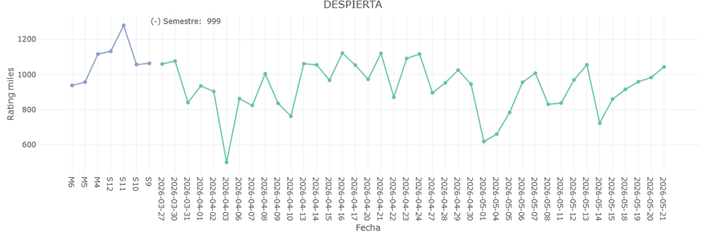

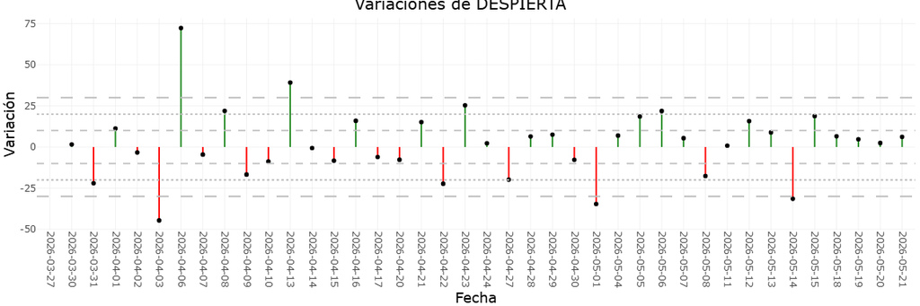

2

### Grid

Cuadrícula comparativa

Muestra todas las gráficas de tendencia en una sola vista miniatura con el mismo eje de tiempo. Proporciona una "fotografía completa" del canal de un vistazo: permite detectar si una caída de audiencia fue sistémica (todos los horarios) o focalizada (solo matutinos, solo prime time, etc.).

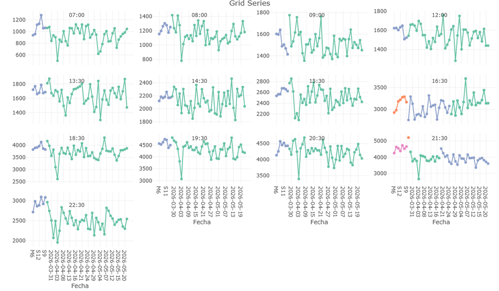

3

### Serie conjunta

Todas las franjas superpuestas

Coloca la tendencia diaria de todos los horarios encimados en una sola gráfica; cada línea y color representa una franja distinta. Permite analizar la jerarquía y el flujo de audiencia a lo largo del día: qué bloque aporta mayor volumen de rating y cómo se comportan las brechas entre programas.

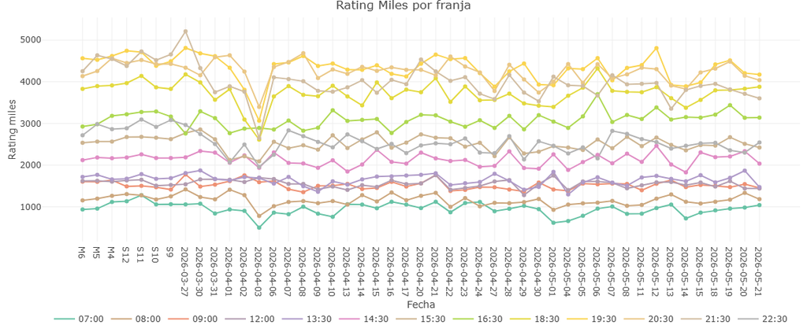

4

### Resumen

Tablas de alertas ejecutivas

Recopila en formato tabla todos los días (últimas 8 semanas) en que un programa tuvo una **variación de rating superior al ±10 %**. El porcentaje aparece resaltado en verde (crecimiento) o rojo (caída). Actúa como bitácora de anomalías: sin necesidad de revisar gráfica por gráfica, el usuario obtiene de inmediato el programa, la fecha y la magnitud del cambio.

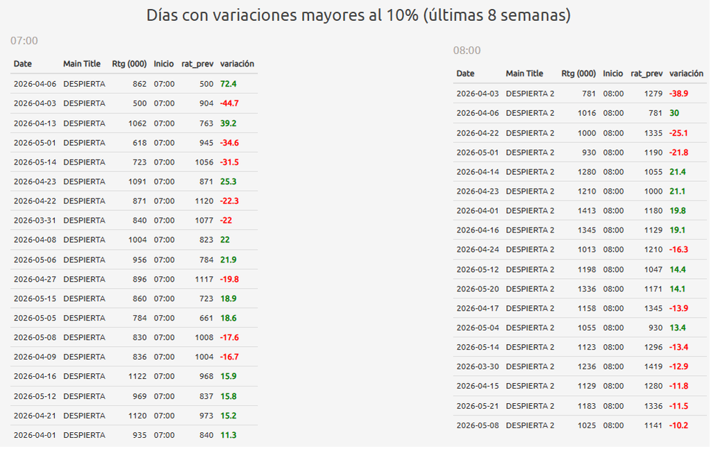